# Índice de confiança nas instituições democráticas

05/12/2020

[output not shown]

## Justificativa Teórica

Uma das características fundamentais para a criação e manutenção de uma instituição o reconhecimento de sua legitimidade.

Para instituições que constituem as democracias liberais comtemporâneas, como as Câmaras Legislativas, o Judiciário, os partidos políticos e o executivo, é fundamental que os cidadãos reconheçam as instituições como pilares do sistema democrático, e por isso, garantidoras de seus direitos e liberdades.

No entanto, é possível observar que discursos que deslegitimam tais instituições vem crescendo no Brasil, em especial ao considerarmos que o presidente eleito em 2018 possui um histórico de críticas ao poder legislativo e ao Supremo Tribunal Federal, algo que continuou se manifestando após sua posse.

## Justificativa Teórica

Portanto, torna-se de grande interesse para a ciência política analisar o quanto esses discursos estão presentes na opnião pública.

Este trabalho visa a realização dessa tarefa a partir do banco de dados do Estudo Eleitoral Brasileiro (ESEB), usando uma questão que indaga o quanto o entrevistado confia nas instituições citadas acima, e dessa forma, criar um índice de confiança nas instituições democráticas.

O gráfico exposto na próxima sessão é o produto desse índice.

```
## $sample.size
## [1] 2506
##
## $number.of.items
## [1] 4
##
## $alpha
## [1] 0.8134191
```

## Gráfico

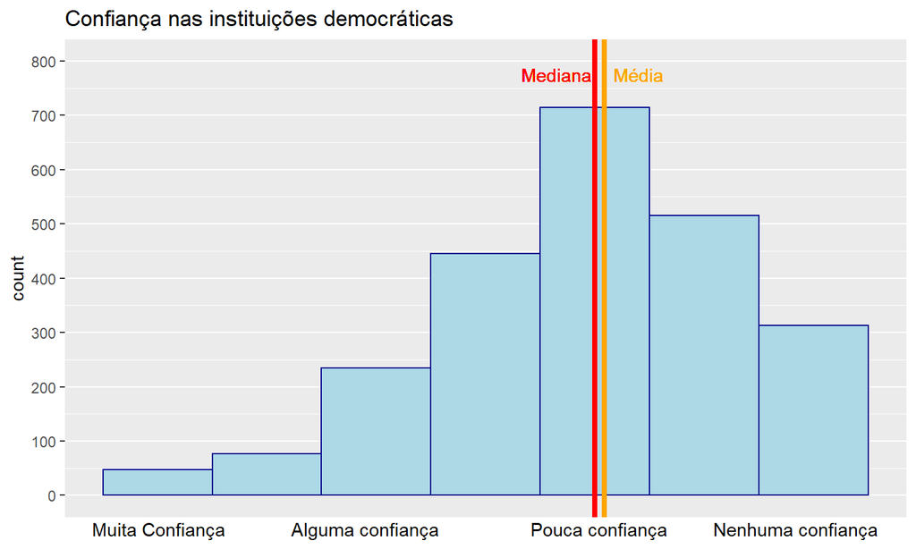